# Homework 02

Xiao, Justin (email: BOX11@pitt.edu)

# Overview

> In this assignment, you’ll explore both numeric and categorical variables and do regression analysis.

You will use the dataset D8 described on DMR (online access via [Pitt network](http://site.ebrary.com.pitt.idm.oclc.org/lib/pitt/docDetail.action?docID=10716644)) Appendix A (data8) for this assignment. The data is `audit.csv` and already included in the repository. The objective is to predict the binary (TARGET_Adjusted) and continuous (RISK_Adjustment) target variables. Create RMarkdown report using this template.  
**hint:** treat the given binary values “1” as “positive” and “0” as “negative”  
**hint:** be careful about missing values in data, try to remove them if there are only a few instances. You will loose 2 points if you directly using missing values without processing them.

The audit.csv data set is an artiﬁcially constructed data set that contains the characteristics of n = 2000 individual tax returns. The data set includes the following variables:

- ID: Unique identiﬁer for each person.
- Age: Age of person.
- Employment: Type of employment.
- Education: Highest level of education.
- Marital: Current marital status.
- Occupation: Type of occupation.
- Income: Amount of income declared.
- Gender: Gender of person.
- Deductions: Total amount of expenses that a person claims in their ﬁnancial statement.
- Hours: Average hours worked on a weekly basis.
- RISK_Adjustment: The continuous target variable; this variable records the monetary amount of any adjustment to the person’s ﬁnancial claims as a result of a productive audit. This variable is a measure of the size of the risk associated with the person.
- TARGET_Adjusted: The binary target variable for classiﬁcation modeling (0/1), indicating nonproductive and productive audits, respectively. Productive audits are those that result in an adjustment being made to a client’s ﬁnancial statement.
1. Read the data description above, and identify and report response variable and predictors.
2. Explore the dataset, and generate both statistical and graphical summary with respect to the numerical and categorical variables.
   1. Generate a summary table for the data. For each numerical variable, list: variable name, mean, median, 1st quartile, 3rd quartile, and standard deviation.
   2. For numerical variables, plot the density distribution. Describe whether the variable has a normal distribution or certain type of skew distribution. **hint:** you can use Shapiro-Wilk normality test to test for normal distribution
   3. For each categorical predictor, generate the conditional histogram plot of response variable.
3. Apply logistic regression analysis to predict TARGET_Adjusted. Evaluate the models through cross-validation and on holdout samples. Interpret the effect of the predictors.
   1. Implement a 10-fold cross-validation scheme by splitting the data into training and testing sets. Use the training set to train a logistic regression model to predict the response variable. Examine the performance of different models by varing the number of predictors. Report the performance of the models on testing set using proper measures (accuracy, precision, recall, F1, AUC) and plots (ROC, lift).
   2. For the best model, compute the odds ratio and interpret the effect of each predictors.
4. Apply linear and non-linear regression analysis to predict RISK_Adjustment. Evaluate the models through 10-fold cross-validation.
   1. Use all predictors in a standard linear regression model to predict the response variable. Report the model performance using RMSE through cross-validation. Use Q-Q plot to check the diagnostics and examine whether the normality is violated. **hint:** You can log transform the response variable if the normality is violated.
   2. Use different combination of predictors in standard linear and non-linear regression models to predict the response variable. (Here we don’t consider interaction terms.) Evaluate which model performs better using RMSE through cross-validation.
   3. From the previous answers,identify your best model, and identify the most important predictor in the model. Explain how you determine the importance of the predictors.

# Problem 1: Identify and report response variable and predictors

```r
## YOUR CODE HERE
audit <- read.csv("audit.csv")
```

YOUR ANSWER for Problem 1. ASW: Response variable: RISK_Adjustment, TARGET_Adjusted Predictor: Age, Employment, Education, Marital, Occupation, Income, Gender, Deductions, Hours

# Problem 2. Data exploration: statistical and graphical summary

```r
## YOUR CODE HERE
Deductions_No0 <- subset(audit, subset=Deductions!=0)

Risk_Ajd_No0 <- subset(audit, subset=RISK_Adjustment!=0)

statTable = matrix(
  c(mean(audit$Age),median(audit$Age),quantile(audit$Age, probs = 0.25),quantile(audit$Age, probs = 0.75),sd(audit$Age),
    mean(audit$Income),median(audit$Income),quantile(audit$Income, probs = 0.25),quantile(audit$Income, probs = 0.75),sd(audit$Income),
    mean(Deductions_No0$Deductions),median(Deductions_No0$Deductions),quantile(Deductions_No0$Deductions, probs = 0.25),quantile(Deductions_No0$Deductions, probs = 0.75),sd(Deductions_No0$Deductions),
    mean(audit$Hours),median(audit$Hours),quantile(audit$Hours, probs = 0.25),quantile(audit$Hours, probs = 0.75),sd(audit$Hours),
    mean(Risk_Ajd_No0$RISK_Adjustment),median(Risk_Ajd_No0$RISK_Adjustment),quantile(Risk_Ajd_No0$RISK_Adjustment, probs = 0.25),quantile(Risk_Ajd_No0$RISK_Adjustment, probs = 0.75),sd(Risk_Ajd_No0$RISK_Adjustment)),
  nrow = 5,
  ncol = 5,
  byrow = T
)
rownames(statTable) = c("Age", "Income", "Deductions", "Hours", "Risk Adjustment")
colnames(statTable) = c("Mean", "Median", "1st Quartile", "3rd Quartile", "sd")
TableF <- as.table(statTable)
TableF
```

```
##                         Mean       Median 1st Quartile 3rd Quartile
## Age                 38.62200     37.00000     28.00000     48.00000
## Income           84688.46004  59768.95000  34433.11750 113842.89750
## Deductions        1628.15261   1568.00000   1160.33333   1977.00000
## Hours               40.07450     40.00000     38.00000     45.00000
## Risk Adjustment  10130.13534   7277.00000   3997.00000  10520.00000
##                           sd
## Age                 13.58475
## Income           69621.64450
## Deductions         507.87884
## Hours               12.15372
## Risk Adjustment  16344.85593
```

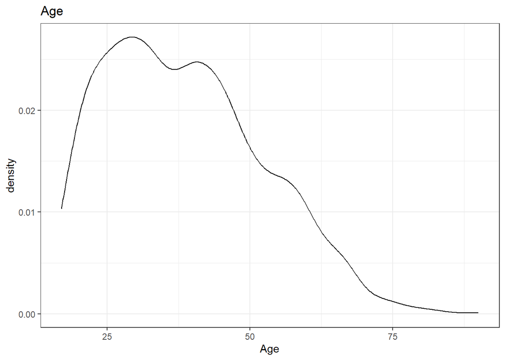

```r
ggplot(data=audit, aes(x=Age)) +
geom_density() + labs(title="Age")
```

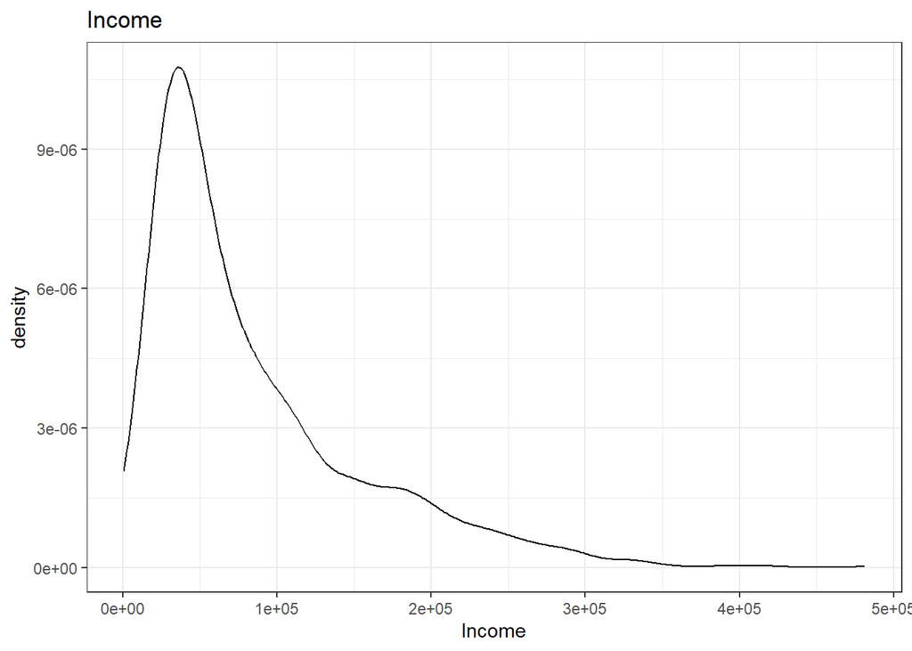

```r
ggplot(data=audit, aes(x=Income)) +
geom_density() + labs(title="Income")
```

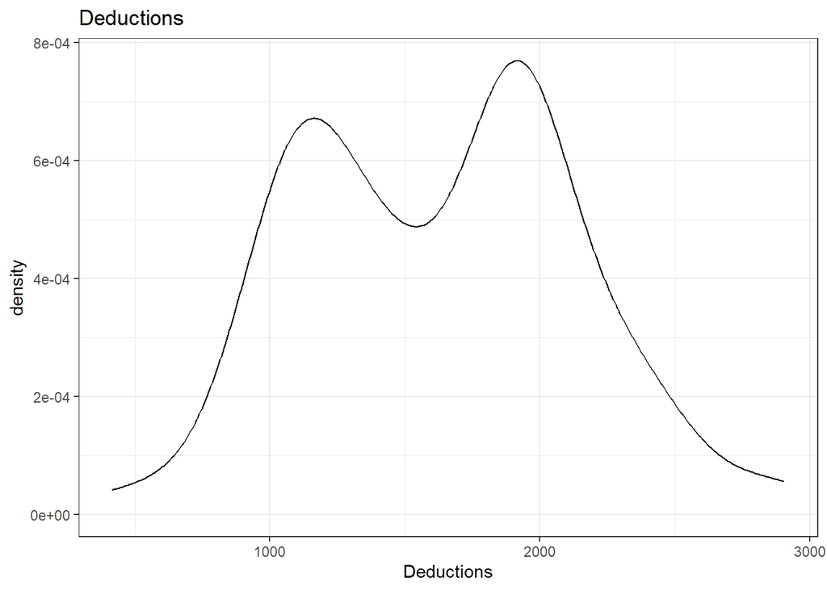

```r
ggplot(data=Deductions_No0, aes(x=Deductions)) +
geom_density() + labs(title="Deductions")
```

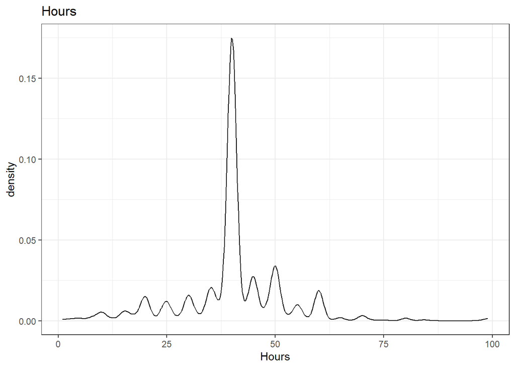

```r
ggplot(data=audit, aes(x=Hours)) +
geom_density() + labs(title="Hours")
```

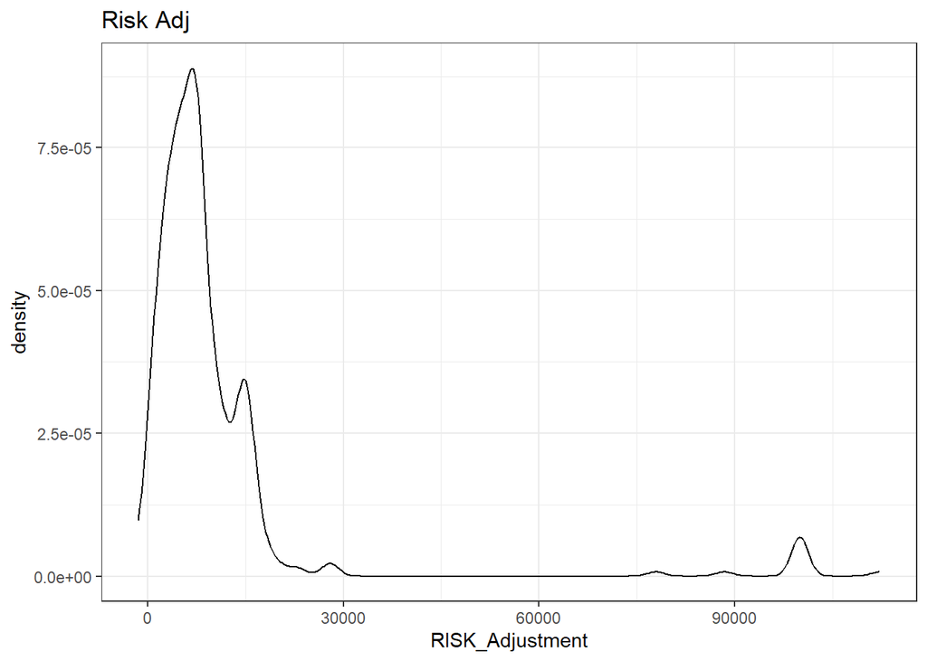

```r
ggplot(data=Risk_Ajd_No0, aes(x=RISK_Adjustment)) +
geom_density() + labs(title="Risk Adj")
```

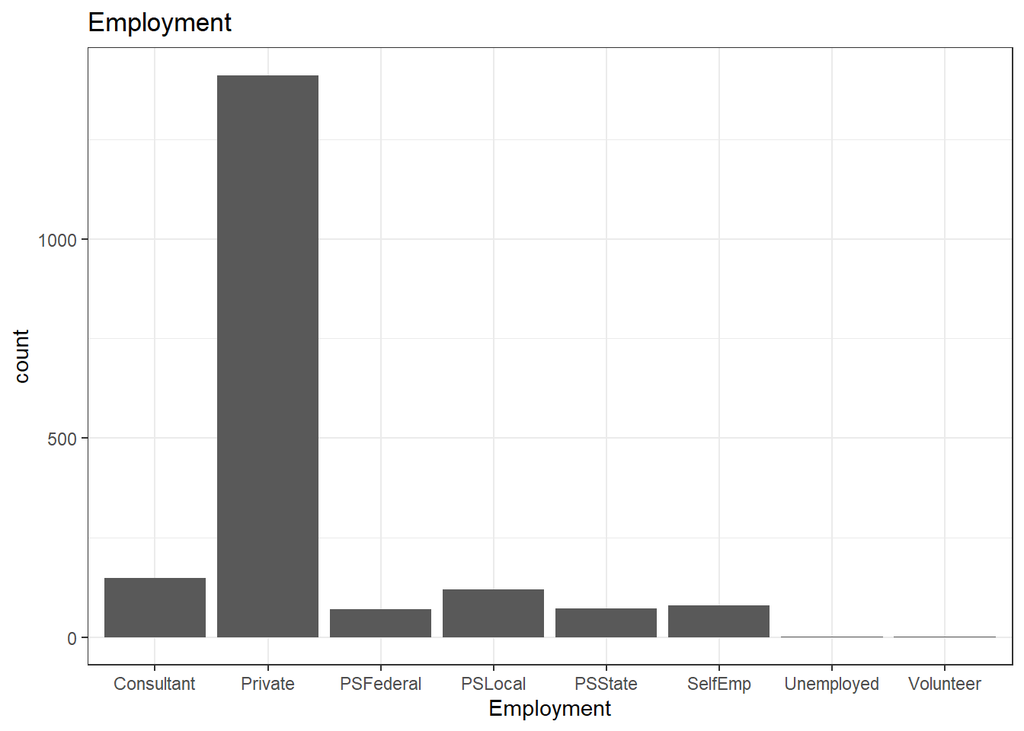

```r
Employment_NoNA <- subset(audit, subset=Employment!="NA")

ggplot(data=Employment_NoNA, aes(x=Employment)) + geom_histogram(stat = "count", position="dodge") + labs(title="Employment")
```

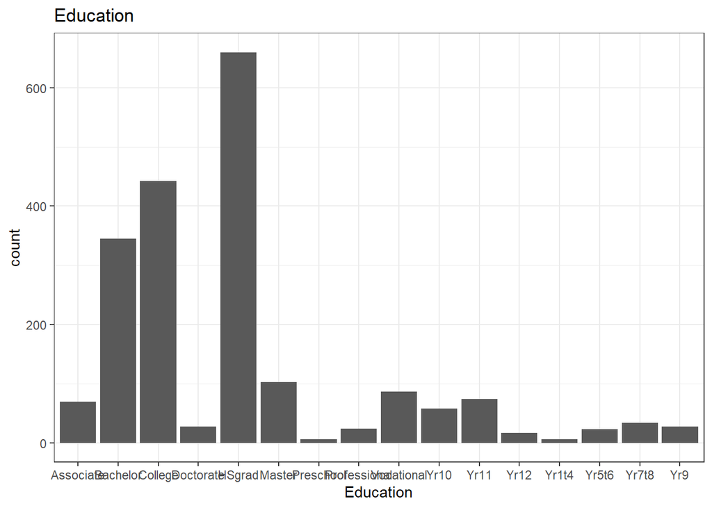

```r
ggplot(data=audit, aes(x=Education)) + geom_histogram(stat = "count", position="dodge") + labs(title="Education")
```

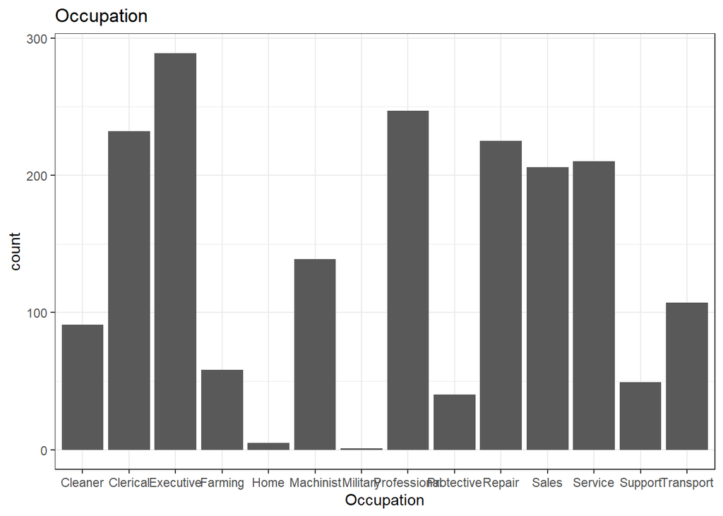

```r
Occupation_NoNA <- subset(audit, subset=Occupation!="NA")
ggplot(data=Occupation_NoNA, aes(x=Occupation)) + geom_histogram(stat = "count", position="dodge") + labs(title="Occupation")
```

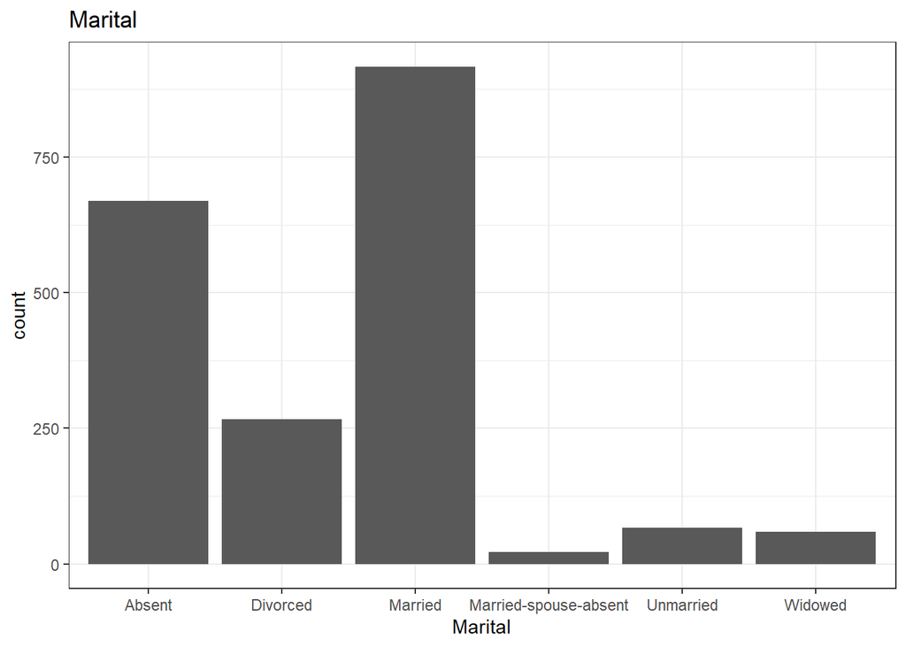

```r
ggplot(data=audit, aes(x=Marital)) + geom_histogram(stat = "count", position="dodge") + labs(title="Marital")
```

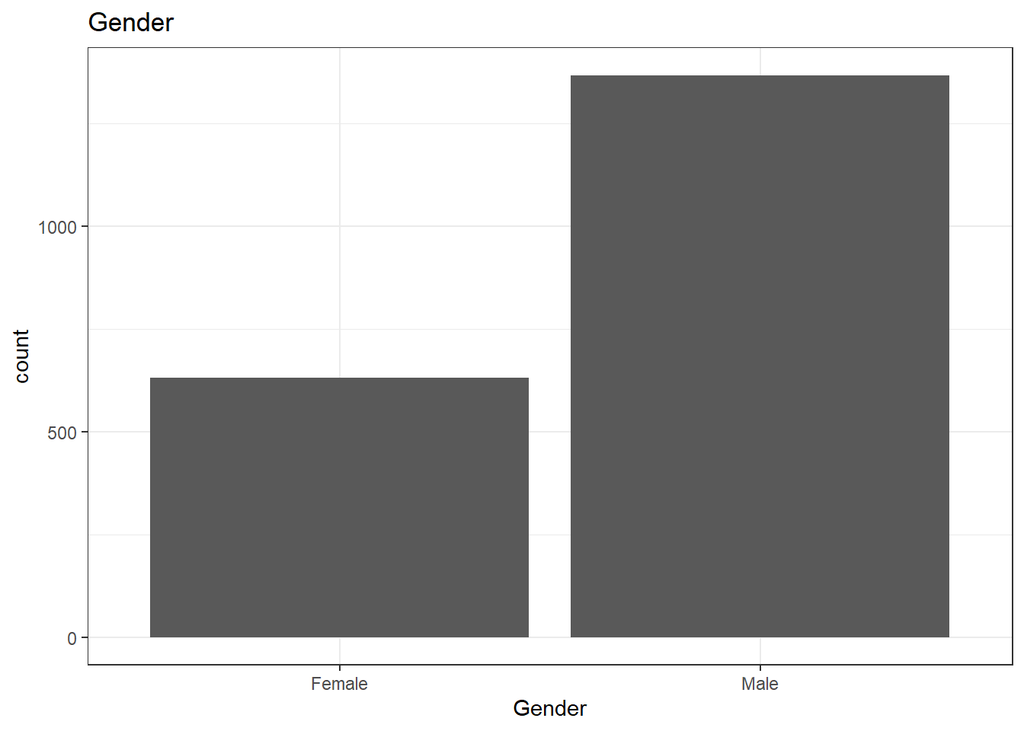

```r
ggplot(data=audit, aes(x=Gender)) + geom_histogram(stat = "count", position="dodge") + labs(title="Gender")
```

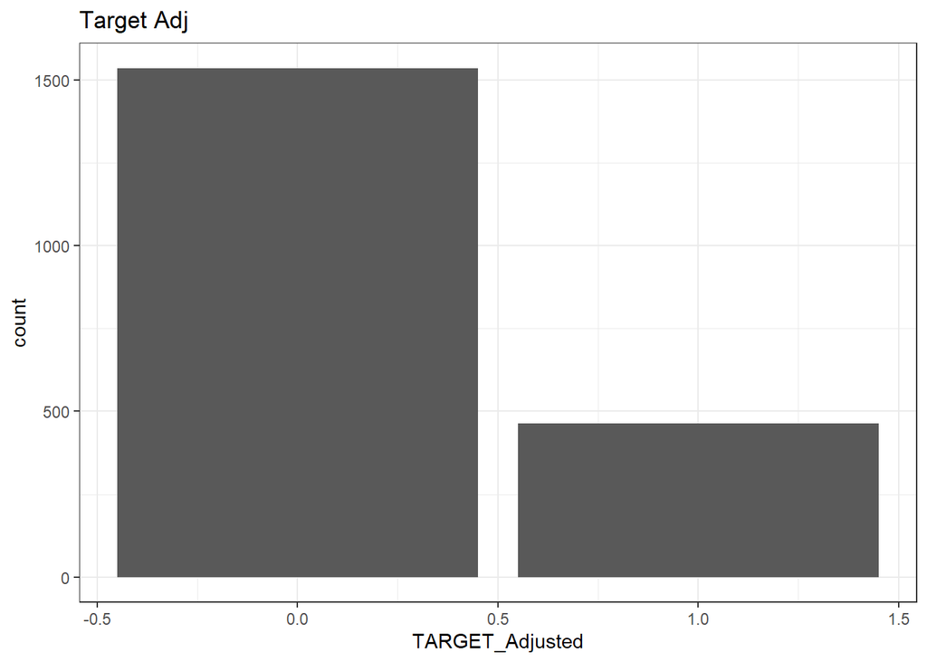

```r
ggplot(data=audit, aes(x=TARGET_Adjusted)) + geom_histogram(stat = "count", position="dodge") + labs(title="Target Adj")
```

# Problem 3. Logistic regression analysis

```r
## YOUR CODE HERE
library(caret)
library(Metrics)
library(ROCR)
library(epitools)
audit_NoNA <- subset(audit, subset=Employment!="NA")
audit_NoNA <- subset(audit_NoNA, subset=Occupation!="NA")

set.seed(2024)
index <- createDataPartition(audit_NoNA$TARGET_Adjusted, p=.8, list=F, time=1)
train_audit <- audit_NoNA[index,]
test_audit <- audit_NoNA[-index,]

train_audit$TARGET_Adjusted[train_audit$TARGET_Adjusted==1] <- "positive"
train_audit$TARGET_Adjusted[train_audit$TARGET_Adjusted==0] <- "negative"
test_audit$TARGET_Adjusted[test_audit$TARGET_Adjusted==1] <- "positive"
test_audit$TARGET_Adjusted[test_audit$TARGET_Adjusted==0] <- "negative"

train_audit$TARGET_Adjusted <- as.factor(train_audit$TARGET_Adjusted)
test_audit$TARGET_Adjusted <- as.factor(test_audit$TARGET_Adjusted)


ctrl <- trainControl(method = "cv", number = 10)
model <- train(TARGET_Adjusted ~ Age + Income + Deductions + Hours + Gender + Employment + Education + Marital + Occupation,
               data = train_audit, method = "glm", family = "binomial", trControl = ctrl)

print(model)
```

```
## Generalized Linear Model
##
## 1520 samples
##    9 predictor
##    2 classes: 'negative', 'positive'
##
## No pre-processing
## Resampling: Cross-Validated (10 fold)
## Summary of sample sizes: 1367, 1368, 1368, 1369, 1368, 1367, ...
## Resampling results:
##
##   Accuracy   Kappa
##   0.8341598  0.5109202
```

```r
summary(model)
```

```
##
## Call:
## NULL
##
## Coefficients:
##                                  Estimate Std. Error z value Pr(>|z|)
## (Intercept)                    -7.755e+00  1.041e+00  -7.448 9.49e-14 ***
## Age                             2.581e-02  7.585e-03   3.402 0.000668 ***
## Income                          4.034e-06  1.656e-06   2.436 0.014834 *
## Deductions                      1.036e-03  2.375e-04   4.360 1.30e-05 ***
## Hours                           3.741e-02  7.527e-03   4.970 6.70e-07 ***
## GenderMale                      3.553e-01  2.775e-01   1.280 0.200453
## EmploymentPrivate               3.347e-01  2.966e-01   1.128 0.259187
## EmploymentPSFederal            -1.373e-01  5.277e-01  -0.260 0.794749
## EmploymentPSLocal              -9.069e-02  4.440e-01  -0.204 0.838135
## EmploymentPSState               6.768e-01  4.986e-01   1.357 0.174650
## EmploymentSelfEmp               3.288e-01  4.150e-01   0.792 0.428192
## EmploymentVolunteer            -1.723e+01  3.956e+03  -0.004 0.996525
## EducationBachelor               4.062e-01  4.207e-01   0.965 0.334340
## EducationCollege               -6.010e-01  4.182e-01  -1.437 0.150692
## EducationDoctorate              1.268e+00  7.629e-01   1.663 0.096381 .
## EducationHSgrad                -7.077e-01  4.112e-01  -1.721 0.085219 .
## EducationMaster                 7.941e-01  5.106e-01   1.555 0.119905
## EducationPreschool             -1.511e+01  1.406e+03  -0.011 0.991424
## EducationProfessional           1.878e+00  7.024e-01   2.673 0.007516 **
## EducationVocational            -8.426e-01  5.801e-01  -1.452 0.146387
## EducationYr10                  -1.318e+00  7.571e-01  -1.740 0.081833 .
## EducationYr11                  -1.045e+00  7.753e-01  -1.347 0.177821
## EducationYr12                  -1.051e+00  1.258e+00  -0.835 0.403576
## EducationYr1t4                 -1.699e+01  1.685e+03  -0.010 0.991955
## EducationYr5t6                 -1.734e+00  1.275e+00  -1.360 0.173858
## EducationYr7t8                 -1.623e+01  7.046e+02  -0.023 0.981622
## EducationYr9                   -2.317e+00  1.188e+00  -1.951 0.051061 .
## MaritalDivorced                 1.488e-01  3.769e-01   0.395 0.692940
## MaritalMarried                  2.817e+00  2.759e-01  10.209  < 2e-16 ***
## `MaritalMarried-spouse-absent`  8.587e-01  8.717e-01   0.985 0.324613
## MaritalUnmarried                6.921e-01  6.062e-01   1.142 0.253581
## MaritalWidowed                  8.632e-01  6.720e-01   1.285 0.198927
## OccupationClerical              1.663e+00  6.903e-01   2.410 0.015974 *
## OccupationExecutive             2.138e+00  6.591e-01   3.243 0.001181 **
## OccupationFarming               5.720e-01  8.515e-01   0.672 0.501714
## OccupationHome                 -1.194e+01  1.734e+03  -0.007 0.994507
## OccupationMachinist             9.922e-01  7.028e-01   1.412 0.157982
## OccupationMilitary             -1.194e+01  3.956e+03  -0.003 0.997592
## OccupationProfessional          1.892e+00  6.837e-01   2.767 0.005656 **
## OccupationProtective            2.512e+00  7.902e-01   3.178 0.001482 **
## OccupationRepair                1.128e+00  6.654e-01   1.695 0.090082 .
## OccupationSales                 1.684e+00  6.769e-01   2.488 0.012839 *
## OccupationService              -9.644e-02  8.072e-01  -0.119 0.904894
## OccupationSupport               1.677e+00  7.886e-01   2.127 0.033431 *
## OccupationTransport             5.613e-01  7.308e-01   0.768 0.442504
## ---
## Signif. codes:  0 '***' 0.001 '**' 0.01 '*' 0.05 '.' 0.1 ' ' 1
##
## (Dispersion parameter for binomial family taken to be 1)
##
##     Null deviance: 1668.8  on 1519  degrees of freedom
## Residual deviance: 1011.9  on 1475  degrees of freedom
## AIC: 1101.9
##
## Number of Fisher Scoring iterations: 16
```

```r
varImp(model)
```

```
## glm variable importance
##
##   only 20 most important variables shown (out of 44)
##
##                        Overall
## MaritalMarried          100.00
## Hours                    48.66
## Deductions               42.69
## Age                      33.31
## OccupationExecutive      31.75
## OccupationProtective     31.11
## OccupationProfessional   27.08
## EducationProfessional    26.16
## OccupationSales          24.35
## Income                   23.84
## OccupationClerical       23.58
## OccupationSupport        20.81
## EducationYr9             19.09
## EducationYr10            17.02
## EducationHSgrad          16.83
## OccupationRepair         16.58
## EducationDoctorate       16.26
## EducationMaster          15.21
## EducationVocational      14.20
## EducationCollege         14.05
```

```r
model$resample
```

```
##     Accuracy     Kappa Resample
## 1  0.8627451 0.5999253   Fold01
## 2  0.8289474 0.4653680   Fold02
## 3  0.8947368 0.7031250   Fold03
## 4  0.7748344 0.2997818   Fold04
## 5  0.8289474 0.5079681   Fold05
## 6  0.8169935 0.4389733   Fold06
## 7  0.8289474 0.5079681   Fold07
## 8  0.8157895 0.4804687   Fold08
## 9  0.8618421 0.5985915   Fold09
## 10 0.8278146 0.5070316   Fold10
```

```r
predictions <- predict(model, newdata = test_audit)
references <- test_audit$TARGET_Adjusted
confusionMatrix(predictions, references)
```

```
## Confusion Matrix and Statistics
##
##           Reference
## Prediction negative positive
##   negative      267       42
##   positive       27       43
##
##                Accuracy : 0.8179
##                  95% CI : (0.7753, 0.8555)
##     No Information Rate : 0.7757
##     P-Value [Acc > NIR] : 0.02606
##
##                   Kappa : 0.4418
##
##  Mcnemar's Test P-Value : 0.09191
##
##             Sensitivity : 0.9082
##             Specificity : 0.5059
##          Pos Pred Value : 0.8641
##          Neg Pred Value : 0.6143
##              Prevalence : 0.7757
##          Detection Rate : 0.7045
##    Detection Prevalence : 0.8153
##       Balanced Accuracy : 0.7070
##
##        'Positive' Class : negative
##
```

```r
Precision <- 267/(267+27)
Recall <- 267/(267+42)
F1 <- 2*Precision*Recall/(Precision+Recall)
Precision
```

```
## [1] 0.9081633
```

```r
Recall
```

```
## [1] 0.8640777
```

```r
F1
```

```
## [1] 0.8855721
```

```r
Pred <- c('negative', 'positive')
Refe <- c('negative', 'positive')
data <- matrix(c(34, 16, 39, 11), nrow=2, ncol=2, byrow=TRUE)
dimnames(data) <- list('Prediction'=Pred, 'Reference'=Refe)

oddsratio(data)
```

```
## $data
##           Reference
## Prediction negative positive Total
##   negative       34       16    50
##   positive       39       11    50
##   Total          73       27   100
##
## $measure
##           odds ratio with 95% C.I.
## Prediction  estimate     lower    upper
##   negative 1.0000000        NA       NA
##   positive 0.6045506 0.2395879 1.480143
##
## $p.value
##           two-sided
## Prediction midp.exact fisher.exact chi.square
##   negative         NA           NA         NA
##   positive   0.271899    0.3678219  0.2600686
##
## $correction
## [1] FALSE
##
## attr(,"method")
## [1] "median-unbiased estimate & mid-p exact CI"
```

```r
model$finalModel
```

```
##
## Call:  NULL
##
## Coefficients:
##                    (Intercept)                             Age
##                     -7.755e+00                       2.581e-02
##                         Income                      Deductions
##                      4.034e-06                       1.036e-03
##                          Hours                      GenderMale
##                      3.741e-02                       3.553e-01
##              EmploymentPrivate             EmploymentPSFederal
##                      3.347e-01                      -1.373e-01
##              EmploymentPSLocal               EmploymentPSState
##                     -9.069e-02                       6.768e-01
##              EmploymentSelfEmp             EmploymentVolunteer
##                      3.288e-01                      -1.723e+01
##              EducationBachelor                EducationCollege
##                      4.062e-01                      -6.010e-01
##             EducationDoctorate                 EducationHSgrad
##                      1.268e+00                      -7.077e-01
##                EducationMaster              EducationPreschool
##                      7.941e-01                      -1.511e+01
##          EducationProfessional             EducationVocational
##                      1.878e+00                      -8.426e-01
##                  EducationYr10                   EducationYr11
##                     -1.318e+00                      -1.045e+00
##                  EducationYr12                  EducationYr1t4
##                     -1.051e+00                      -1.699e+01
##                 EducationYr5t6                  EducationYr7t8
##                     -1.734e+00                      -1.623e+01
##                   EducationYr9                 MaritalDivorced
##                     -2.317e+00                       1.488e-01
##                 MaritalMarried  `MaritalMarried-spouse-absent`
##                      2.817e+00                       8.587e-01
##               MaritalUnmarried                  MaritalWidowed
##                      6.921e-01                       8.632e-01
##             OccupationClerical             OccupationExecutive
##                      1.663e+00                       2.138e+00
##              OccupationFarming                  OccupationHome
##                      5.720e-01                      -1.194e+01
##            OccupationMachinist              OccupationMilitary
##                      9.922e-01                      -1.194e+01
##         OccupationProfessional            OccupationProtective
##                      1.892e+00                       2.512e+00
##               OccupationRepair                 OccupationSales
##                      1.128e+00                       1.684e+00
##              OccupationService               OccupationSupport
##                     -9.644e-02                       1.677e+00
##            OccupationTransport
##                      5.613e-01
##
## Degrees of Freedom: 1519 Total (i.e. Null);  1475 Residual
## Null Deviance:       1669
## Residual Deviance: 1012  AIC: 1102
```

# Problem 4. Regression analysis

```r
## YOUR CODE HERE
set.seed(1)
ctrl <- trainControl(method = "cv", number = 10)
lin_model <- train(RISK_Adjustment ~ poly(Age, degree = 4) + poly(Income ,degree = 1) + poly(Deductions, degree = 2) + poly(Hours, degree = 1) + Gender + Employment + Education + Marital + Occupation,
               data = audit_NoNA, method = "lm", trControl = ctrl)
print(lin_model)
```

```
## Linear Regression
##
## 1899 samples
##    9 predictor
##
## No pre-processing
## Resampling: Cross-Validated (10 fold)
## Summary of sample sizes: 1710, 1709, 1709, 1709, 1709, 1708, ...
## Resampling results:
##
##   RMSE      Rsquared    MAE
##   7686.785  0.08524348  3052.165
##
## Tuning parameter 'intercept' was held constant at a value of TRUE
```

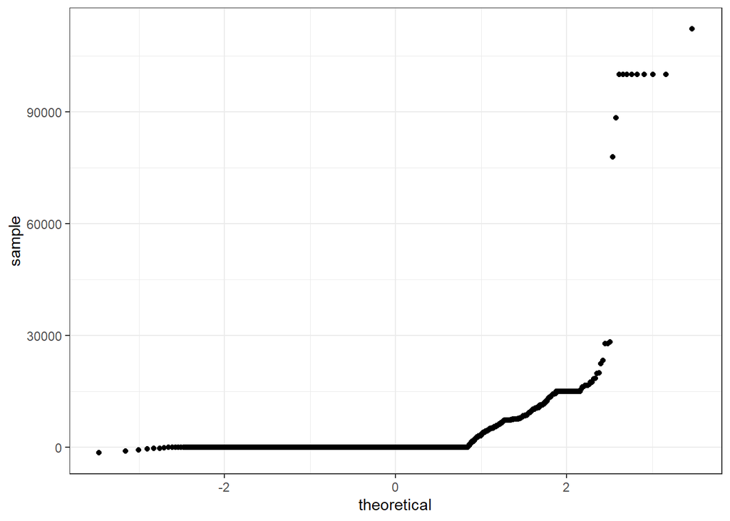

```r
ggplot(audit_NoNA, aes(sample = RISK_Adjustment))+stat_qq()
```

```r
summary(lin_model)
```

```
##
## Call:
## lm(formula = .outcome ~ ., data = dat)
##
## Residuals:
##    Min     1Q Median     3Q    Max
## -15848  -2521   -620    719 103473
##
## Coefficients:
##                                  Estimate Std. Error t value Pr(>|t|)
## (Intercept)                       3769.08    1582.59   2.382   0.0173 *
## `poly(Age, degree = 4)1`         17406.92   10358.36   1.680   0.0930 .
## `poly(Age, degree = 4)2`        -13911.60    9313.18  -1.494   0.1354
## `poly(Age, degree = 4)3`        -17301.07    8298.69  -2.085   0.0372 *
## `poly(Age, degree = 4)4`         16289.11    8131.41   2.003   0.0453 *
## `poly(Income, degree = 1)`        7631.25    9475.86   0.805   0.4207
## `poly(Deductions, degree = 2)1`  14954.65    8028.83   1.863   0.0627 .
## `poly(Deductions, degree = 2)2`   3393.44    8042.89   0.422   0.6731
## `poly(Hours, degree = 1)`        14725.59    9037.65   1.629   0.1034
## GenderMale                        -112.50     506.97  -0.222   0.8244
## EmploymentPrivate                -1495.44     714.16  -2.094   0.0364 *
## EmploymentPSFederal              -2048.00    1197.99  -1.710   0.0875 .
## EmploymentPSLocal                  753.86    1043.19   0.723   0.4700
## EmploymentPSState                -1885.27    1180.07  -1.598   0.1103
## EmploymentSelfEmp                 -204.28    1124.40  -0.182   0.8559
## EmploymentVolunteer              -4508.88    8055.62  -0.560   0.5757
## EducationBachelor                 -466.66    1081.61  -0.431   0.6662
## EducationCollege                 -1259.86    1059.90  -1.189   0.2347
## EducationDoctorate                1185.09    1964.85   0.603   0.5465
## EducationHSgrad                  -1568.97    1042.14  -1.506   0.1324
## EducationMaster                    995.50    1313.80   0.758   0.4487
## EducationPreschool               -2117.99    3436.89  -0.616   0.5378
## EducationProfessional             8848.10    1972.16   4.487 7.69e-06 ***
## EducationVocational              -1731.86    1325.06  -1.307   0.1914
## EducationYr10                       61.92    1488.35   0.042   0.9668
## EducationYr11                    -1919.45    1449.76  -1.324   0.1857
## EducationYr12                    -2046.81    2315.90  -0.884   0.3769
## EducationYr1t4                   -4382.19    3696.19  -1.186   0.2359
## EducationYr5t6                   -2719.47    2038.23  -1.334   0.1823
## EducationYr7t8                   -2443.52    1738.30  -1.406   0.1600
```

[output cut: 10 more lines]

```
## OccupationMachinist              -1112.94    1082.54  -1.028   0.3040
## OccupationMilitary                 522.74    8003.55   0.065   0.9479
## OccupationProfessional            -172.68    1093.44  -0.158   0.8745
## OccupationProtective              -757.29    1586.65  -0.477   0.6332
## OccupationRepair                  -981.53    1006.97  -0.975   0.3298
## OccupationSales                   -289.95    1027.56  -0.282   0.7778
## OccupationService                 -651.83    1012.15  -0.644   0.5197
## OccupationSupport                  768.15    1445.18   0.532   0.5951
## OccupationTransport              -2229.17    1148.61  -1.941   0.0524 .
## ---
## Signif. codes:  0 '***' 0.001 '**' 0.01 '*' 0.05 '.' 0.1 ' ' 1
##
## Residual standard error: 7888 on 1850 degrees of freedom
## Multiple R-squared:  0.104,  Adjusted R-squared:  0.08071
## F-statistic: 4.471 on 48 and 1850 DF,  p-value: < 2.2e-16
```

```r
varImp(lin_model)
```

```
## lm variable importance
##
##   only 20 most important variables shown (out of 48)
##
##                                 Overall
## MaritalMarried                   100.00
## EducationProfessional             93.62
## EmploymentPrivate                 43.35
## `poly(Age, degree = 4)3`          43.15
## `poly(Age, degree = 4)4`          41.44
## OccupationTransport               40.13
## `poly(Deductions, degree = 2)1`   38.48
## EmploymentPSFederal               35.27
## `poly(Age, degree = 4)1`          34.66
## `poly(Hours, degree = 1)`         33.58
## EmploymentPSState                 32.91
## EducationHSgrad                   30.98
## `poly(Age, degree = 4)2`          30.73
## EducationYr9                      29.77
## MaritalDivorced                   28.90
## EducationYr7t8                    28.88
## OccupationFarming                 27.49
## EducationYr5t6                    27.38
## EducationYr11                     27.16
## EducationVocational               26.81
```

YOUR ANSWER for Problem 4. ASW: As the table of importance shows, the most important predictor is Marital.